# Part I - (Ford GoBike System Data)

## by (Bader Ababtain)

This data set includes information about individual rides made in a bike-sharing system covering the greater San Francisco Bay area.

## Preliminary Wrangling

```python
# import all packages and set plots to be embedded inline
import numpy as np
import pandas as pd
import matplotlib.pyplot as plt
import seaborn as sns
```

> Load in your dataset and describe its properties through the questions below. Try and motivate your exploration goals through this section.

```python
bike=pd.read_csv('201902-fordgobike-tripdata.csv')
```

```python
# overview of data shape and types
print(bike.shape)
print('-' *20)
print(bike.info())
print('-' *20)
print(bike.dtypes)
bike.head()
```

```
(183412, 16)
--------------------
<class 'pandas.core.frame.DataFrame'>
RangeIndex: 183412 entries, 0 to 183411
Data columns (total 16 columns):
 #   Column                   Non-Null Count   Dtype
---  ------                   --------------   -----
 0   duration_sec             183412 non-null  int64
 1   start_time               183412 non-null  object
 2   end_time                 183412 non-null  object
 3   start_station_id         183215 non-null  float64
 4   start_station_name       183215 non-null  object
 5   start_station_latitude   183412 non-null  float64
 6   start_station_longitude  183412 non-null  float64
 7   end_station_id           183215 non-null  float64
 8   end_station_name         183215 non-null  object
 9   end_station_latitude     183412 non-null  float64
 10  end_station_longitude    183412 non-null  float64
 11  bike_id                  183412 non-null  int64
 12  user_type                183412 non-null  object
 13  member_birth_year        175147 non-null  float64
 14  member_gender            175147 non-null  object
 15  bike_share_for_all_trip  183412 non-null  object
dtypes: float64(7), int64(2), object(7)
memory usage: 22.4+ MB
None
--------------------
duration_sec                 int64
start_time                  object
end_time                    object
start_station_id           float64
start_station_name          object
start_station_latitude     float64
start_station_longitude    float64
end_station_id             float64
end_station_name            object
end_station_latitude       float64
end_station_longitude      float64
bike_id                      int64
user_type                   object
member_birth_year          float64
member_gender               object
bike_share_for_all_trip     object
dtype: object
```

|  | duration_sec | start_time | end_time | start_station_id | start_station_name | start_station_latitude | start_station_longitude | end_station_id | end_station_name | end_station_latitude | end_station_longitude | bike_id | user_type | member_birth_year | member_gender | bike_share_for_all_trip |
| --- | --- | --- | --- | --- | --- | --- | --- | --- | --- | --- | --- | --- | --- | --- | --- | --- |
| 0 | 52185 | 2019-02-28 17:32:10.1450 | 2019-03-01 08:01:55.9750 | 21.0 | Montgomery St BART Station (Market St at 2nd St) | 37.789625 | -122.400811 | 13.0 | Commercial St at Montgomery St | 37.794231 | -122.402923 | 4902 | Customer | 1984.0 | Male | No |
| 1 | 42521 | 2019-02-28 18:53:21.7890 | 2019-03-01 06:42:03.0560 | 23.0 | The Embarcadero at Steuart St | 37.791464 | -122.391034 | 81.0 | Berry St at 4th St | 37.775880 | -122.393170 | 2535 | Customer | NaN | NaN | No |
| 2 | 61854 | 2019-02-28 12:13:13.2180 | 2019-03-01 05:24:08.1460 | 86.0 | Market St at Dolores St | 37.769305 | -122.426826 | 3.0 | Powell St BART Station (Market St at 4th St) | 37.786375 | -122.404904 | 5905 | Customer | 1972.0 | Male | No |
| 3 | 36490 | 2019-02-28 17:54:26.0100 | 2019-03-01 04:02:36.8420 | 375.0 | Grove St at Masonic Ave | 37.774836 | -122.446546 | 70.0 | Central Ave at Fell St | 37.773311 | -122.444293 | 6638 | Subscriber | 1989.0 | Other | No |
| 4 | 1585 | 2019-02-28 23:54:18.5490 | 2019-03-01 00:20:44.0740 | 7.0 | Frank H Ogawa Plaza | 37.804562 | -122.271738 | 222.0 | 10th Ave at E 15th St | 37.792714 | -122.248780 | 4898 | Subscriber | 1974.0 | Male | Yes |

```python
# descriptive statistics for numeric variables
bike.describe()
```

|  | duration_sec | start_station_id | start_station_latitude | start_station_longitude | end_station_id | end_station_latitude | end_station_longitude | bike_id | member_birth_year |
| --- | --- | --- | --- | --- | --- | --- | --- | --- | --- |
| count | 183412.000000 | 183215.000000 | 183412.000000 | 183412.000000 | 183215.000000 | 183412.000000 | 183412.000000 | 183412.000000 | 175147.000000 |
| mean | 726.078435 | 138.590427 | 37.771223 | -122.352664 | 136.249123 | 37.771427 | -122.352250 | 4472.906375 | 1984.806437 |
| std | 1794.389780 | 111.778864 | 0.099581 | 0.117097 | 111.515131 | 0.099490 | 0.116673 | 1664.383394 | 10.116689 |
| min | 61.000000 | 3.000000 | 37.317298 | -122.453704 | 3.000000 | 37.317298 | -122.453704 | 11.000000 | 1878.000000 |
| 25% | 325.000000 | 47.000000 | 37.770083 | -122.412408 | 44.000000 | 37.770407 | -122.411726 | 3777.000000 | 1980.000000 |
| 50% | 514.000000 | 104.000000 | 37.780760 | -122.398285 | 100.000000 | 37.781010 | -122.398279 | 4958.000000 | 1987.000000 |
| 75% | 796.000000 | 239.000000 | 37.797280 | -122.286533 | 235.000000 | 37.797320 | -122.288045 | 5502.000000 | 1992.000000 |
| max | 85444.000000 | 398.000000 | 37.880222 | -121.874119 | 398.000000 | 37.880222 | -121.874119 | 6645.000000 | 2001.000000 |

```python
bike.duplicated().sum()# checkfor duplicates
```

```
0
```

```python
bike.isnull().sum()
```

```
duration_sec                  0
start_time                    0
end_time                      0
start_station_id            197
start_station_name          197
start_station_latitude        0
start_station_longitude       0
end_station_id              197
end_station_name            197
end_station_latitude          0
end_station_longitude         0
bike_id                       0
user_type                     0
member_birth_year          8265
member_gender              8265
bike_share_for_all_trip       0
dtype: int64
```

Data cleaning:

the first is Missing values in start_station_id, start_station_name, end_station_id end_station_name, member_birth_year, member_gender columns

```python
bike.dropna(inplace=True)# Drop the rows with missing values
```

```python
bike.isnull().any().sum()#test
```

```
0
```

the second issue: start_time and end_time columns are in string (object) and bike_id need to be converted to object

# Convert the columns to datetime and id to string

```python
bike['start_time'] = pd.to_datetime(bike['start_time'])
bike['end_time'] = pd.to_datetime(bike['end_time'])
bike['bike_id'] =bike.bike_id.astype(str)
```

```python
bike.dtypes#to check
```

```
duration_sec                        int64
start_time                 datetime64[ns]
end_time                   datetime64[ns]
start_station_id                  float64
start_station_name                 object
start_station_latitude            float64
start_station_longitude           float64
end_station_id                    float64
end_station_name                   object
end_station_latitude              float64
end_station_longitude             float64
bike_id                            object
user_type                          object
member_birth_year                 float64
member_gender                      object
bike_share_for_all_trip            object
dtype: object
```

### What is the structure of your dataset?

> The dataset comprises 183,412 rides with 16 features, primarily numeric in nature. However, some variables, such as 'start_time' and 'end_time', have incorrect data types and should be converted to datetime. Additionally, the columns 'start_station_id', 'start_station_name', 'end_station_id', 'end_station_name', 'member_birth_year', and 'member_gender' contain missing values.

### What is/are the main feature(s) of interest in your dataset?

> The main features of interest in this dataset is duration_sec, start_time, and user_type column.and I'm interested in analyzing the time of day and the day of the week when the most trips are taken.

### What features in the dataset do you think will help support your investigation into your feature(s) of interest?

> start_date variable

```python
#Extracting the day, month and year colunns fron the start and end date
import datetime as dt
bike['start_day'] = bike['start_time'].dt.day_name()
bike['start_month'] = bike['start_time'].dt.month_name()
bike['start_hr'] = bike['start_time'].dt.hour
bike['end_day'] = bike['end_time'].dt.day_name()
bike['end_month'] = bike['end_time'].dt.month_name()
bike['end_hr'] = bike['end_time'].dt.hour
bike.head(3)
```

|  | duration_sec | start_time | end_time | start_station_id | start_station_name | start_station_latitude | start_station_longitude | end_station_id | end_station_name | end_station_latitude | ... | user_type | member_birth_year | member_gender | bike_share_for_all_trip | start_day | start_month | start_hr | end_day | end_month | end_hr |
| --- | --- | --- | --- | --- | --- | --- | --- | --- | --- | --- | --- | --- | --- | --- | --- | --- | --- | --- | --- | --- | --- |
| 0 | 52185 | 2019-02-28 17:32:10.145 | 2019-03-01 08:01:55.975 | 21.0 | Montgomery St BART Station (Market St at 2nd St) | 37.789625 | -122.400811 | 13.0 | Commercial St at Montgomery St | 37.794231 | ... | Customer | 1984.0 | Male | No | Thursday | February | 17 | Friday | March | 8 |
| 2 | 61854 | 2019-02-28 12:13:13.218 | 2019-03-01 05:24:08.146 | 86.0 | Market St at Dolores St | 37.769305 | -122.426826 | 3.0 | Powell St BART Station (Market St at 4th St) | 37.786375 | ... | Customer | 1972.0 | Male | No | Thursday | February | 12 | Friday | March | 5 |
| 3 | 36490 | 2019-02-28 17:54:26.010 | 2019-03-01 04:02:36.842 | 375.0 | Grove St at Masonic Ave | 37.774836 | -122.446546 | 70.0 | Central Ave at Fell St | 37.773311 | ... | Subscriber | 1989.0 | Other | No | Thursday | February | 17 | Friday | March | 4 |

3 rows × 22 columns

## Univariate Exploration

I'll begin by examining the distribution of the primary variables of interest: start_day, time_of_day, user_type, and duration_sec. ,end_month,member_gender

Q:What day of the week has the most trips?

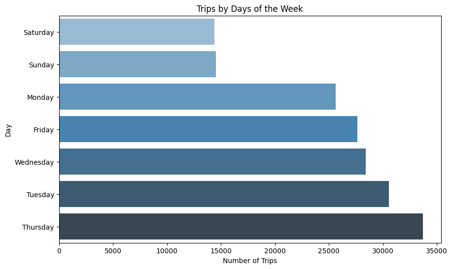

```python
# Get the count of trips made in each day of the week
plt.figure(figsize=[10, 6])
base_color = sns.color_palette()[0]
sns.barplot(y=bike['start_day'].value_counts(ascending=True).index,
            x=bike['start_day'].value_counts(ascending=True).values,
            palette='Blues_d')
plt.title('Trips by Days of the Week')
plt.xlabel('Number of Trips')
plt.ylabel('Day')
plt.show()
```

It turns out that Thursday has the most trips, followed by Tuesday and Wednesday. It can be observed that Saturday and Sunday have the fewest trips, which is reasonable considering they are not working days

Q:What is the average trip duration

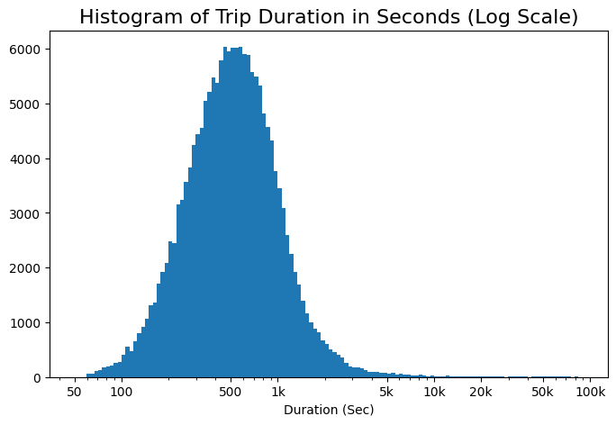

```python
log_binsize = 0.025
bins = 10 ** np.arange(1.7, np.log10(bike['duration_sec'].max()) + log_binsize, log_binsize)

plt.figure(figsize=[8, 5])
plt.hist(data=bike, x='duration_sec', bins=bins)
plt.xscale('log')
plt.xticks([50, 1e2, 5e2, 1e3, 5e3, 1e4, 2e4, 5e4, 1e5], [50, '100', '500', '1k', '5k', '10k', '20k', '50k', '100k'])
plt.xlabel('Duration (Sec)')

# Set the title for the histogram
plt.title("Histogram of Trip Duration in Seconds (Log Scale)", fontsize=16)

plt.show()
```

q1-WHAT IS THE month that have the higher end_month frequency q2-WHAT IS THE GENDER THAT have highest frequncey ride q3- WHAT IS THE common USER TYPE

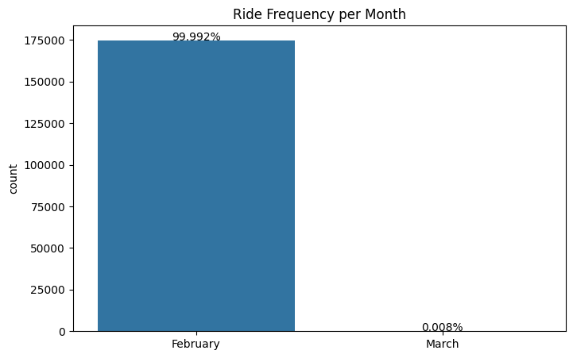

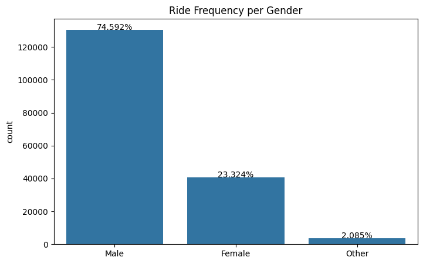

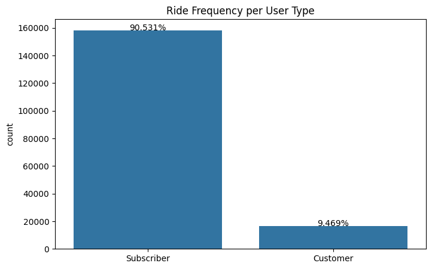

```python
# a function as requested to avoid reptive code
def create_countplot(data, x_var, hue_var=None, order=None, title=None, xlabel=None, rotation=0):
    plt.figure(figsize=[8, 5])
    ax = sns.countplot(data=data, x=x_var, hue=hue_var, order=order, color=sns.color_palette()[0])
    total = len(data)
    for p in ax.patches:
        percentage = '{:.3f}%'.format(100 * p.get_height() / total)
        x = p.get_x() + p.get_width() / 2
        y = p.get_height() + .05
        ax.annotate(percentage, (x, y), ha='center')
    plt.title(title)
    plt.xlabel(xlabel)
    plt.xticks(rotation=rotation)
    plt.show()

# Sample usage of the function
# Plot for ride frequency per month
create_countplot(bike, 'end_month', title='Ride Frequency per Month', order=bike.end_month.value_counts().index)

# Plot for ride frequency per gender
create_countplot(bike, 'member_gender', title='Ride Frequency per Gender', order=bike.member_gender.value_counts().index)

# Plot for ride frequency per user type
create_countplot(bike, 'user_type', title='Ride Frequency per User Type', order=bike.user_type.value_counts().index)
```

All the trips started and ended in February except for a very few which ended in March more than 70% of riders are male more than 90% of riders are subscriber

### Discuss the distribution(s) of your variable(s) of interest. Were there any unusual points? Did you need to perform any transformations?

As it would be expected in most cases, most trips (about 90%) are taken by the subscribers with the remaining 10% being just casual riders. In the case of larger percentage of trips by subscribers; who wouldn't want to make efficient use of their subscription?. Or in another view, the Subscribers might be using the bikes for daily commute while customers just use it for leisure activities

Also, almost 75% of the riders that's taken trips are males which is like 3 times that of the females with the remaining 2% regarded as other. for end_month All the trips started and ended in February except for a very few which ended in March 70% of bike riders are male

### Of the features you investigated, were there any unusual distributions? Did you perform any operations on the data to tidy, adjust, or change the form of the data? If so, why did you do this?

Quality issues for many columns, which is the dtype is not suitable with it's data We have to add some column to extend our time- based analysis

## Bivariate Exploration

```python
cust = bike['user_type']=='Customer'
subs = bike['user_type']=='Subscriber'
```

Q:HOW HAS Higher AVERAGE duration based on user Type

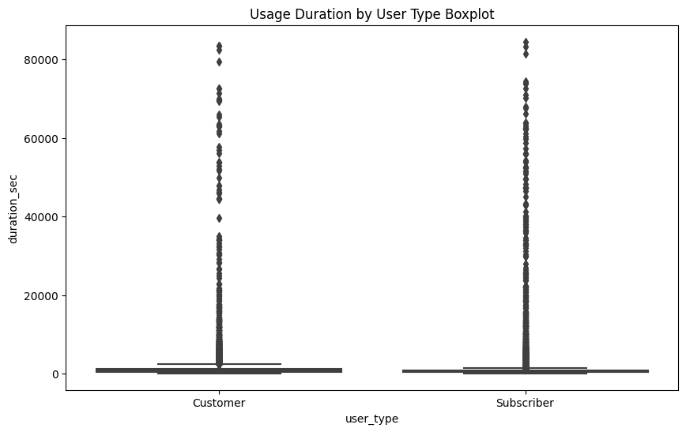

```python
plt.figure(figsize=(10,6))
plt.title('Usage Duration by User Type Boxplot')
sns.boxplot(data=bike, x='user_type', y='duration_sec');
```

```python
# Average trip duration for Customer/Casual

bike[cust].duration_sec.mean()
```

```
1310.656102861282
```

```python
 #Average trip duration for Subscriber/Member

bike[subs].duration_sec.mean()
```

```
640.5513050395869
```

it seems that duration average for Customer is higher than Subscriber

```python
categoric_vars = ['user_type', 'member_gender', 'bike_share_for_all_trip', 'start_day','end_day', 'start_hr', 'end_hr']
```

Q: DOES THE male or female spent higher average than male and averge bike share diffrtent averge time accros types

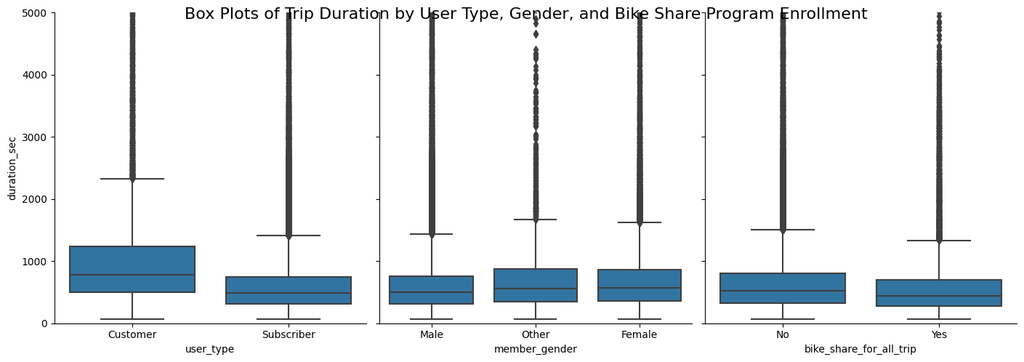

```python
g = sns.PairGrid(data=bike, y_vars='duration_sec', x_vars=['user_type', 'member_gender', 'bike_share_for_all_trip'], height=5, aspect=1.5)
g.map(sns.boxplot, color=sns.color_palette()[0])
plt.ylim([0, 5000])
g.fig.set_size_inches(14,5);
plt.suptitle("Box Plots of Trip Duration by User Type, Gender, and Bike Share Program Enrollment", fontsize=16)
plt.show()
```

it appears that customers spend more time on average compare to subscribers while the female gender spend higher time on average than male.

Bike share for all trip tends to be similar on average across all types .

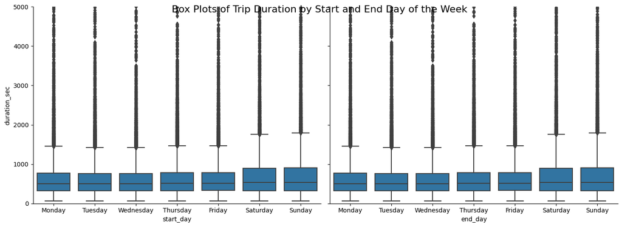

```python
plt.figure(figsize=[10, 10])
days_of_week = ["Monday", "Tuesday", "Wednesday", "Thursday", "Friday", "Saturday", "Sunday"]
g = sns.PairGrid(data=bike, y_vars='duration_sec', x_vars=['start_day', 'end_day'], height=7, aspect=1.5)
g.map(sns.boxplot, color=sns.color_palette()[0], order=days_of_week)
plt.ylim([0, 5000])

# Set the main title for the entire PairGrid
plt.suptitle("Box Plots of Trip Duration by Start and End Day of the Week", fontsize=16)

g.fig.set_size_inches(14, 5)
plt.show()
```

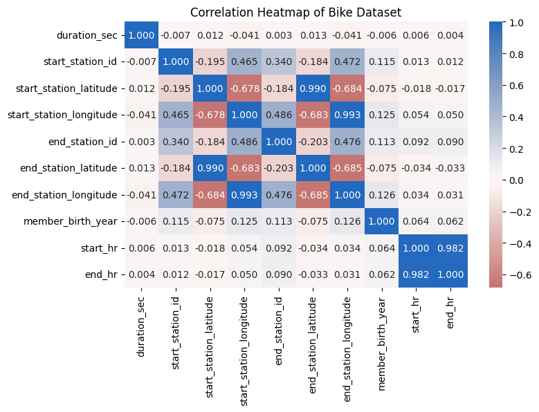

```python
 #Calculate the correlation matrix for the DataFrame
corr_matrix = bike.corr()

# Create a heatmap of the correlation matrix
plt.figure(figsize=[8, 5])
sns.heatmap(corr_matrix, annot=True, fmt='.3f', cmap='vlag_r', center=0)

# Show the plot
plt.title('Correlation Heatmap of Bike Dataset')
plt.show()
```

q:what is the peak hours of the day

# scatter plot

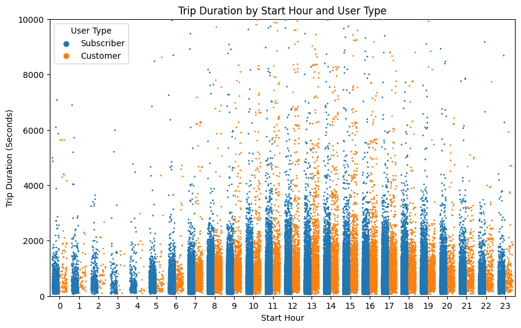

```python
plt.figure(figsize=[10,6])
sns.stripplot(data=bike, x='start_hr', y='duration_sec', hue='user_type', size=2,jitter=0.35,dodge=True)
plt.xlabel("Start Hour")
plt.ylabel("Trip Duration (Seconds)")
plt.title("Trip Duration by Start Hour and User Type")
plt.ylim(0,10000)
# Display the legend and the plot
plt.legend(title='User Type')
plt.show()
```

Q:WHO HAS Higher average trip duration by gender?

|  | member_gender | duration_sec |
| --- | --- | --- |
| 0 | Female | 778.872761 |
| 1 | Male | 672.394851 |
| 2 | Other | 997.328489 |

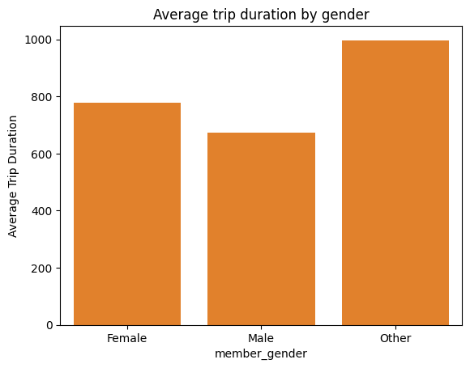

```python
# Average trip duration mean plot
group = bike[['member_gender','duration_sec']].groupby(['member_gender'],as_index=False).mean()
# show analysis
display(group)

sns.barplot(x='member_gender', y='duration_sec', data=group,color=sns.color_palette()[1])
plt.title("Average trip duration by gender")
plt.ylabel("Average Trip Duration")
plt.show()
```

we can deduce the other has highest average trip

### Did you observe any interesting relationships between the other features (not the main feature(s) of interest)?

The user gender named "other" had the highest ride duration, followed by the female with the male having the least trip duration.

## Multivariate Exploration

Q:Who travel more customer or subscriber?

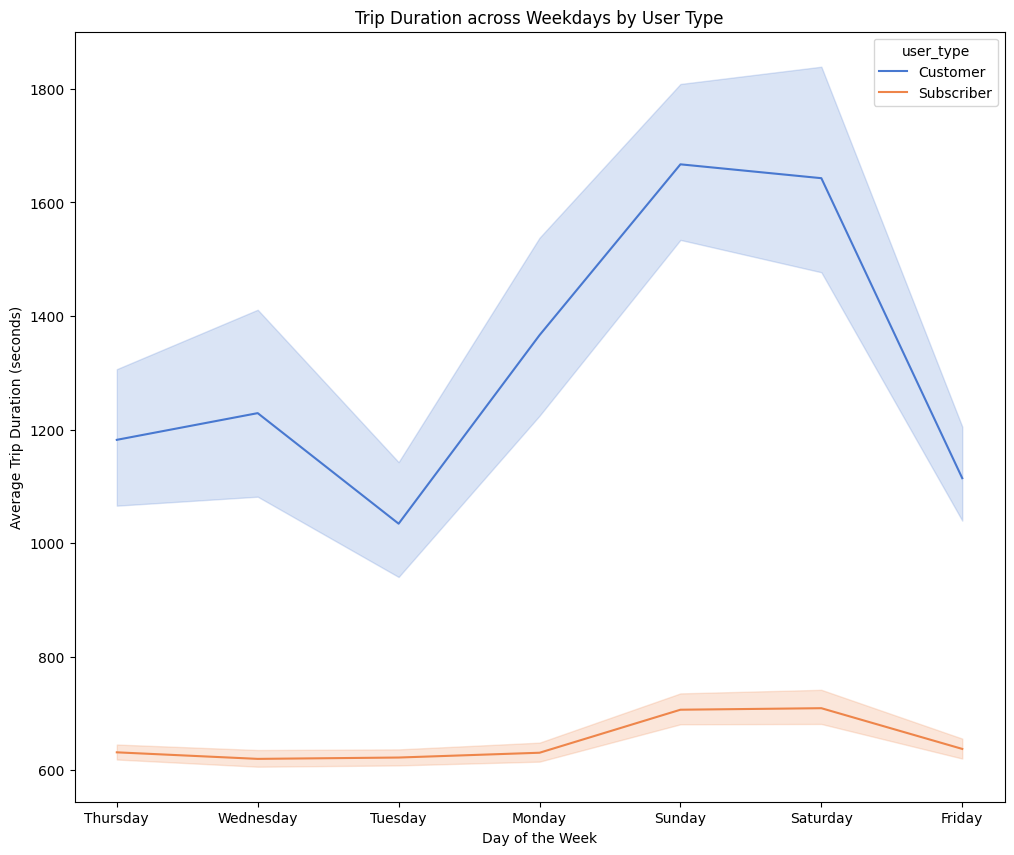

```python
plt.figure(figsize=[12, 10])

# Use lineplot
ax = sns.lineplot(data=bike, x='start_day', y='duration_sec', hue='user_type',
                  palette=sns.color_palette("muted"))

plt.title('Trip Duration across Weekdays by User Type')
plt.ylabel('Average Trip Duration (seconds)')
plt.xlabel('Day of the Week')
plt.show()
```

Q:Does participation in the "Bike Share for All" program affect the trip duration differently for male and female riders?

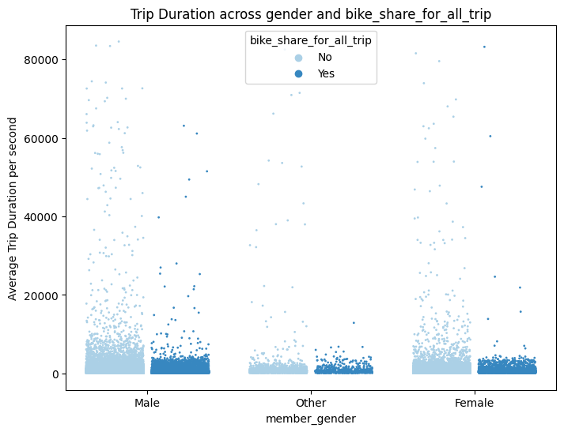

```python
fig = plt.figure(figsize = [8,6])
ax = sns.stripplot(data = bike, x ='member_gender', y = 'duration_sec', hue = 'bike_share_for_all_trip',
           palette = 'Blues',size=2,jitter=0.35, dodge =True)
plt.title('Trip Duration across gender and bike_share_for_all_trip')
plt.ylabel('Average Trip Duration per second')
plt.show();
```

yes for both male and female E

Q:can you list the range who have moreusers

[figure not shown]

```python
# facet plot
g=sns.FacetGrid(data=bike,col='bike_share_for_all_trip')
#the indvidual subplots (facets)
g.map(sns.boxplot,"member_birth_year","user_type","member_gender",whis=10,dodge=True,width=0.75,notch=True)
plt.suptitle("Faceted box plot of Duration by user type and gender ,by bike Sgare program enrollement".title())
g.fig.set_size_inches(14,5);
```

Age group between (25years - 40years) appear to be the popular users

### Talk about some of the relationships you observed in this part of the investigation. Were there features that strengthened each other in terms of looking at your feature(s) of interest?

> Subscribers have shorter usage times than Customers.